# HW1 solutions to problems 3 and 4

#### Authors: Zhongxia Yan, Tony Wang

# Setup

```python
import numpy as np
from cvxopt import solvers
solvers.options['show_progress'] = False
from cvxopt import matrix
import matplotlib.pyplot as plt
```

```python
# From plotBoundary.py
def plot_decision_boundary(X, Y, scoreFn, contour_values=[-1, 0, 1], title=""):
    """
    Plot the decision boundary. For that, we asign a score to
    each point in the mesh [x_min, m_max] x [y_min, y_max].

    X is data matrix (each row is a data point)
    Y is desired output (1 or -1)
    scoreFn is a function of a data point
    contour_values is a list of values to plot
    """

    x_min, x_max = X[:, 0].min() - 1, X[:, 0].max() + 1
    y_min, y_max = X[:, 1].min() - 1, X[:, 1].max() + 1
    h = max((x_max - x_min) / 200.0, (y_max - y_min) / 200.0)
    xx, yy = np.meshgrid(np.arange(x_min, x_max, h), np.arange(y_min, y_max, h))
    zz = np.array([scoreFn(x) for x in np.c_[xx.ravel(), yy.ravel()]])
    zz = zz.reshape(xx.shape)

    plt.figure()
    CS = plt.contour(
        xx, yy, zz, contour_values, colors="green", linestyles="solid", linewidths=2
    )
    plt.clabel(CS, fontsize=9, inline=1)
    # Plot the training points
    plt.scatter(X[:, 0], X[:, 1], c=(1.0 - Y).ravel(), s=50, cmap=plt.cm.cool)
    plt.title(title)
    plt.axis("tight")
```

# 3. Support vector machine

## 3.1

```python
def train_svm(X, y, C=1, print_matrix=False):
    """
    inputs
    X: data matrix, shape (N, d)
    y: label matrix, shape (N,)
    C: coefficient of slack terms in primal optimization, scalar

    returns
    w: weight, shape (N,)
    b: bias, scalar
    """

    N = X.shape[0]
    Xy = X * y.reshape(N, 1)
    P = Xy.dot(Xy.T)
    q = -np.ones(N)

    G = np.concatenate((np.eye(N), -np.eye(N)))
    h = np.concatenate((C * np.ones(N), np.zeros(N)))

    A = y.reshape(1, N)
    b = np.zeros(1)

    if print_matrix:
        print('Inputs to solver')
        for array in ['P', 'q', 'G', 'h', 'A', 'b']:
            print(array + ':')
            print(eval(array))

    sol = solvers.qp(matrix(P), matrix(q), matrix(G), matrix(h), matrix(A), matrix(b))
    alphas = np.array(sol['x'])
    alphas[alphas < 1e-4] = 0

    w = (alphas.reshape(N, 1) * y.reshape(N, 1) * X).sum(axis=0)
    b = (y - X.dot(w))[(0 < alphas.reshape(N)) & (alphas.reshape(N) < C - 1e-4)].mean()
    return w, b

def get_pred_svm(w, b):
    return lambda x: w.dot(x) + b
```

```python
pos = np.array([(2, 2), (3, 2)])
neg = np.array([(-1, 0), (-2, -3)])
X_small = np.concatenate((pos, neg))
y_small = np.concatenate((np.ones(len(pos)), -np.ones(len(neg))))[:len(X_small)]

print('X_small shape', X_small.shape)
print('y_small shape', y_small.shape, '\n')
w, b = train_svm(X_small, y_small, print_matrix=True)
```

```
X_small shape (4, 2)
y_small shape (4,)

Inputs to solver
P:
[[ 8. 10.  2. 10.]
 [10. 13.  3. 12.]
 [ 2.  3.  1.  2.]
 [10. 12.  2. 13.]]
q:
[-1. -1. -1. -1.]
G:
[[ 1.  0.  0.  0.]
 [ 0.  1.  0.  0.]
 [ 0.  0.  1.  0.]
 [ 0.  0.  0.  1.]
 [-1. -0. -0. -0.]
 [-0. -1. -0. -0.]
 [-0. -0. -1. -0.]
 [-0. -0. -0. -1.]]
h:
[1. 1. 1. 1. 0. 0. 0. 0.]
A:
[[ 1.  1. -1. -1.]]
b:
[0.]
```

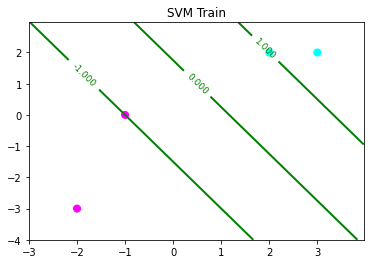

```python
plot_decision_boundary(X_small, y_small, get_pred_svm(w, b), title='SVM Train')
```

The support vectors are (-1, 0) and (2, 2)

##### Below is a note about finding the bias $b$ in soft-margin SVMs in general. We don't use the method below for the code below because it's too much effort for an edge case, and instead we just assume that a support vector on the margin exists (although this may not be true). The note is just for your curiosity and understanding.

Once we find $\alpha$ we can obtain $w$ and calculate bias $b$ by looking for points on the margin boundary, $y_i (w^T x_i + b) = 1$. These points corresponds to the case where $0 < \alpha_i < C$. What if we have no such point where this holds? I.e. what if $\alpha_i = C$ or $\alpha_i = 0$ for all $i$?

If $y$ has multiple classes, not all $\alpha_i = 0$, since that would suggest that $w^* = 0$ and that the SVM will predict the same class for every point.

Then consider only the support vectors, where $\alpha_i = C$. In this case $y_i (w^T x_i + b) = 1 - \xi_i < 1$. We can't directly solve for $b$ in this case any more, unfortunately, so let's plug the optimal values of $w$ back into the primal objective and take a look. $$\min_{w, b} \frac{1}{2} \lVert w\rVert^2 + C \sum_i \max \{0, 1 - y_i (w^T x_i + b) \}$$

After plugging in the optimal $w$, we can aim to find $b$ to minimize the objective. $$\mathrm{argmin}_b \frac{1}{2} \lVert w\rVert^2 + C \sum_i \max \{0, 1 - y_i (w^T x_i + b) \} = \mathrm{argmin}_b \sum_i \max \{0, 1 - y_i (w^T x_i + b) \}$$

Since we already solved for the optimal $\alpha$, we know which $i$ are on the wrong side of the margin boundary since $\alpha_i = C$, and has $y_i (w^T x_i + b) < 1$ therefore $1 - y_i (w^T x_i + b) > 0$. The other points have $1 - y_i (w^T x_i + b) \leq 0$ so we can ignore them. Then the above $\mathrm{argmin}$ reduces to

$$\mathrm{argmin}_b \sum_{\{i|\alpha_i = C\}} \max \{0, 1 - y_i (w^T x_i + b) \} = \mathrm{argmin}_b \sum_{\{i|\alpha_i = C\}} 1 - y_i (w^T x_i + b) = \mathrm{argmin}_b b \sum_{\{i|\alpha_i = C\}} -y_i$$

subject to constraints $1 - y_i (w^T x_i + b) > 0$ for $\{i | \alpha_i = C \}$.

You can see that if there's an equal number of positively-labeled and negatively-labeled support vectors, then $\sum_{\{i|\alpha_i = C\}} -y_i = 0$, and any $b$ that satisfies the contraints is optimal. You can imagine that these positively-labeled and negatively-labeled points are within the margin, and as long as you slide the margin up and down without any of the points crossing the margin boundary, the optimal value of the primal objective stays the same. Actually in this case the problem has multiple optimal solutions (the convex optimization solver just finds one), and you can imagine another $\alpha'$ that's not returned by the solver, but results in the same optimal value as $\alpha$, but puts one of the support vectors on the margin boundary, and there exists an $i$ such that $\alpha_i = C$ and $1 - y_i (w^T x_i + b) < 0$ while $0 < \alpha_i' < C$ and $1 - y_i (w'^T x_i + b') = 0$.

On the other hand, we will show that in this case it's not possible to have $\sum_{\{i|\alpha_i = C\}} -y_i \neq 0$, which suggests that there is an unequal number of positively-labeled and negatively-labeled support vectors inside the margin boundary (with no support vectors on the margin boundary). Assume for contradiction that the previous scenario is possible, then when we solve the optimization problem above, $b$ will shift the margins to minimize the total slack, while still obeying the constraints. But since $b$ cannot shift the margin so that a support vector lies on the margin boundary (since earlier we said there were no $0 < \alpha_i < C$), the optimal value is worse than the optimal value for an $\alpha'$ which does have a support vector on the margin boundary. But then $\alpha$ would not be optimal, and we have a contradiction.

## 3.2

```python
def run_svm(dataset, C=0.1):
    train = np.loadtxt('data/data' + dataset + '_train.csv')
    X_train = train[:, 0:2]
    y_train = train[:, 2]

    # Training
    w, b = train_svm(X_train, y_train, C=0.1)
    pred_svm = get_pred_svm(w, b)

    preds = np.array([pred_svm(x) for x in X_train])
    print('Training error', (preds * y_train <= 0).mean())
    plot_decision_boundary(X_train, y_train, pred_svm, title='SVM Train')

    valid = np.loadtxt('data/data' + dataset + '_validate.csv')
    X_val = valid[:, 0:2]
    y_val = valid[:, 2]

    plot_decision_boundary(X_val, y_val, pred_svm, title='SVM Validation')

    preds = np.array([pred_svm(x) for x in X_val])
    print('Validation error', (preds * y_val <= 0).mean())
```

```
Dataset 1
Training error 0.0
Validation error 0.0
```

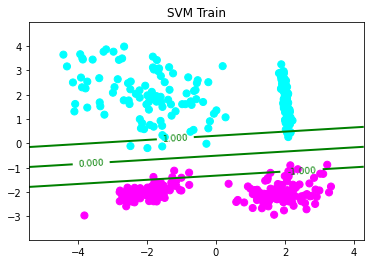

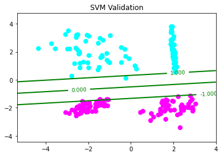

```python
print('Dataset 1')
run_svm('1')
```

```
Dataset 2
Training error 0.175
Validation error 0.175
```

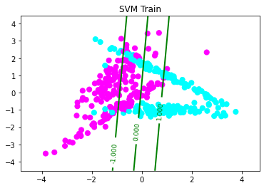

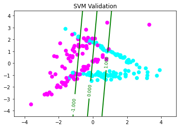

```python
print('Dataset 2')
run_svm('2')
```

```
Dataset 3
Training error 0.025
Validation error 0.04
```

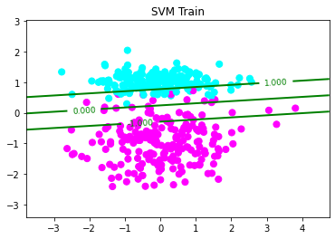

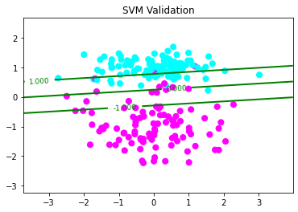

```python
print('Dataset 3')
run_svm('3')
```

```
Dataset 4
Training error 0.31
Validation error 0.3025
```

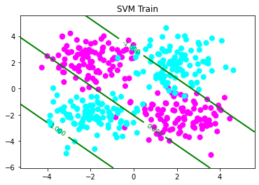

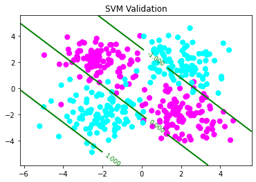

```python
print('Dataset 4')
run_svm('4')
```

## 3.3

```python
def train_kernel_svm(X, y, k=None, C=1):
    """
    inputs
    X: data matrix, shape (N, d)
    y: label matrix, shape (N,)
    k: if k is None, then compute the kernel by XX^T; else k could be a function or precomputed matrix
    C: coefficient of slack terms in primal optimization, scalar

    returns
    w: weight, shape (N,)
    b: bias, scalar
    """

    N = len(y)
    if callable(k):
        K = k(X, X)
    elif k is None:
        K = X.dot(X.T)
    else:
        K = k

    P = K.reshape(N, N) * y.reshape(N, 1).dot(y.reshape(1, N))
    q = -np.ones(N)

    G = np.concatenate((np.eye(N), -np.eye(N)))
    h = np.concatenate((C * np.ones(N), np.zeros(N)))

    A = y.reshape(1, N)
    b = np.zeros(1)

    sol = solvers.qp(matrix(P), matrix(q), matrix(G), matrix(h), matrix(A), matrix(b))
    alpha = np.array(sol['x'])
    alpha[alpha < 1e-4] = 0
    alpha = alpha.reshape(-1)

    is_support_vector = (0 < alpha) & (alpha < C)
    y_sv = y[is_support_vector]
    X_sv = X[is_support_vector]
    b = (y_sv - ((alpha * y).reshape(-1, 1) * ker(X, X_sv)).sum(axis=0)).mean()

    return alpha, b

def get_pred_kernel_svm(alpha, b, X, y, ker):
    return lambda x: (alpha * y * ker(X, x).reshape(-1)).sum(axis=0) + b

ker_linear = lambda X1, X2: X1.dot(X2.T)

def ker_rbf(X1, X2, gamma):
    if len(X1.shape) == 1:
        X1 = X1.reshape(1, -1) # (N1, d)
    if len(X2.shape) == 1:
        X2 = X2.reshape(1, -1) # (N2, d)
    X1 = np.expand_dims(X1, axis=1) # (N1, 1, d)
    X2 = np.expand_dims(X2, axis=0) # (1, N2, d)

    # broadcasting trick
    return np.exp(-gamma * np.sum((X1 - X2) ** 2, axis=2))
```

### Small example for test

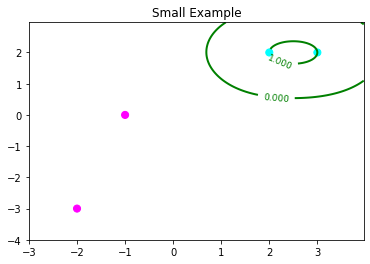

```python
pos = np.array([(2, 2), (3, 2)])
neg = np.array([(-1, 0), (-2, -3)])
X_small = np.concatenate((pos, neg))
y_small = np.concatenate((np.ones(len(pos)), -np.ones(len(neg))))[:len(X_small)]

ker = lambda X1, X2: ker_rbf(X1, X2, gamma=1)
alpha, b = train_kernel_svm(X_small, y_small, k=ker, C=1)
pred_kernel_svm = get_pred_kernel_svm(alpha, b, X_small, y_small, ker)

plot_decision_boundary(X_small, y_small, pred_kernel_svm, title='Small Example')
```

### Full data examples

```python
def run_kernel_svm(name='1', ker=ker_linear, C=1):
    train = np.loadtxt('data/data' + name + '_train.csv')
    X_train = train[:, 0:2].copy()
    y_train = train[:, 2].copy()

    alpha, b = train_kernel_svm(X_train, y_train, k=ker, C=C)
    pred_kernel_svm = get_pred_kernel_svm(alpha, b, X_train, y_train, ker)

    preds = np.array([pred_kernel_svm(x) for x in X_train])
    print('Training error', (preds * y_train <= 0).mean())
    plot_decision_boundary(X_train, y_train, pred_kernel_svm, title='SVM Train')

    validate = np.loadtxt('data/data' + name + '_validate.csv')
    X_val = validate[:, 0:2]
    y_val = validate[:, 2]

    preds = np.array([pred_kernel_svm(x) for x in X_val])
    print('Validation error', (preds * y_val <= 0).mean())
    plot_decision_boundary(X_val, y_val, pred_kernel_svm, title='SVM Validation')
```

```
Training error 0.01
Validation error 0.0
```

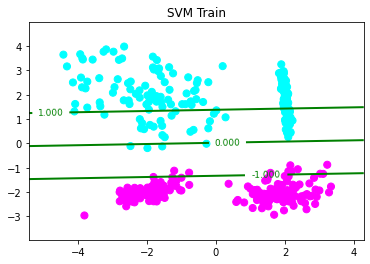

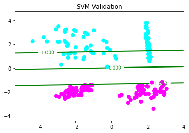

```python
run_kernel_svm(name='1', ker=ker_linear, C=0.01)
```

```
Training error 0.0
Validation error 0.0
```

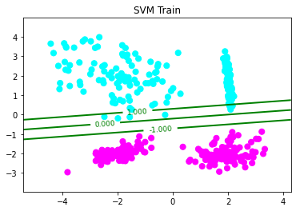

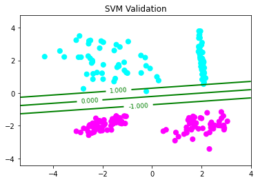

```python
run_kernel_svm(name='1', ker=ker_linear, C=100)
```

```
Training error 0.0025
Validation error 0.0
```

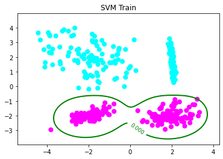

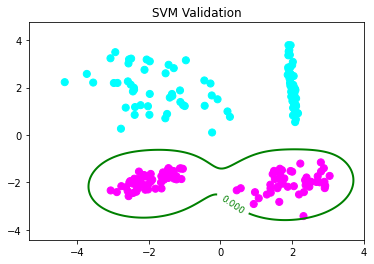

```python
run_kernel_svm(name='1', ker=lambda X1, X2: ker_rbf(X1, X2, gamma=1), C=0.01)
```

```
Training error 0.0
Validation error 0.0
```

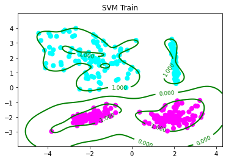

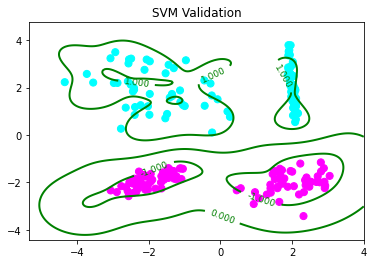

```python
run_kernel_svm(name='1', ker=lambda X1, X2: ker_rbf(X1, X2, gamma=1), C=100)
```

### 3.3.a

Increasing C decreases the margin until all data is not within the margin

### 3.3.b

Number of support vectors decrease because less data is in the margin

### 3.3.c

Maximizing the margin on the training set for a specific value of C may overfit to the training set, and it would be better to use the validation accuracy to choose a good value for C.

# 4 Soft-Margin SVM with Pegasos

## 4.1

```python
from tqdm import tqdm

def train_pegasos(X, y, epochs=1000, lam=1):
    t = 0
    w = np.zeros(X.shape[1])
    b = 0
    for _ in tqdm(range(epochs)):
        for xi, yi in zip(X, y):
            t += 1
            eta = 1 / (t * lam)
            if yi * (w.dot(xi) + b) < 1:
                w = (1 - eta * lam) * w + eta * yi * xi
                b = b + eta * yi
            else:
                w = (1 - eta * lam) * w
    return w, b

def get_pred_pegasos(w, b):
    return lambda x: w.dot(x) + b
```

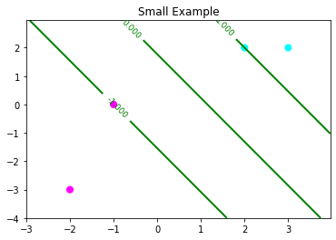

```python
pos = np.array([(2, 2), (3, 2)])
neg = np.array([(-1, 0), (-2, -3)])
X_small = np.concatenate((pos, neg))
y_small = np.concatenate((np.ones(len(pos)), -np.ones(len(neg))))[:len(X_small)]

w, b = train_pegasos(X_small, y_small, epochs=10000)
pred_pegasos = get_pred_pegasos(w, b)

plot_decision_boundary(X_small, y_small, pred_pegasos, title='Small Example')
```

## 4.2

```python
def run_pegasos(name='1', epochs=1000, lam=2e-2):
    train = np.loadtxt('data/data' + name + '_train.csv')
    X_train = train[:,0:2]
    y_train = train[:,2]

    w, b = train_pegasos(X_train, y_train, epochs=epochs, lam=lam)
    pred_pegasos = get_pred_pegasos(w, b)

    plot_decision_boundary(X_train, y_train, pred_pegasos, title='Pegasos Linear SVM')
```

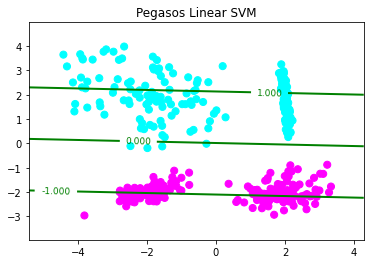

```python
run_pegasos(name='1', epochs=1000, lam=2)
```

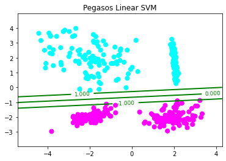

```python
run_pegasos(name='1', epochs=20000, lam=2e-3)
```

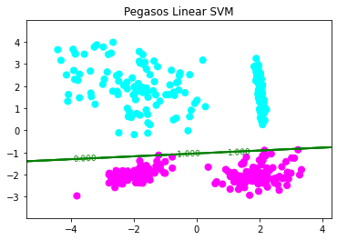

```python
run_pegasos(name='1', epochs=20000, lam=2e-10)
```

Margin decreases as lambda decreases.

## 4.3

```python
def train_kernel_pegasos(K, y, epochs=1000, lam=1):
    t = 0
    a = np.zeros(K.shape[1])
    for _ in tqdm(range(epochs)):
        for i, (ki, yi) in enumerate(zip(K, y)):
            t += 1
            eta = 1 / (t * lam)

            if yi * a.dot(ki) < 1:
                a *= 1 - eta * lam
                a[i] += eta * yi
            else:
                a *= 1 - eta * lam
    return a

def get_pred_kernel_pegasos(alpha, X, ker):
    return lambda x: (alpha * ker(X, x).reshape(-1)).sum(axis=0)
```

You should make a new prediction for a new point x by calculating the kernel value between x and the support vector points. There is the same sparsity in the support vectors as in alpha.

## 4.4

```python
def ker_laplace(X1, X2, gamma):
    if len(X1.shape) == 1:
        X1 = X1.reshape(1, -1) # (N1, d)
    if len(X2.shape) == 1:
        X2 = X2.reshape(1, -1) # (N2, d)
    X1 = np.expand_dims(X1, axis=1) # (N1, 1, d)
    X2 = np.expand_dims(X2, axis=0) # (1, N2, d)

    # broadcasting trick
    return np.exp(-gamma * np.sqrt(np.sum((X1 - X2) ** 2, axis=2)))

def run_kernel_pegasos(name='1', epochs=1000, lam=0.02, gamma=2):
    train = np.loadtxt('data/data' + name + '_train.csv')
    X_train = train[:, 0:2]
    y_train = train[:, 2]

    ker = lambda X1, X2: ker_laplace(X1, X2, gamma=gamma)
    K = ker(X_train, X_train)

    alpha = train_kernel_pegasos(K, y_train, lam=lam, epochs=epochs)
    print((alpha > 1e-4).mean())
    pred_kernel_pegasos = get_pred_kernel_pegasos(alpha, X_train, ker)

    plot_decision_boundary(X_train, y_train, pred_kernel_pegasos, title='Pegasos Laplace Kernel SVM')
```

```
0.3925
```

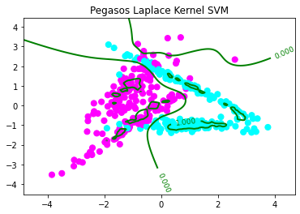

```python
run_kernel_pegasos('2', epochs=2000, gamma=2)
```

```
0.32
```

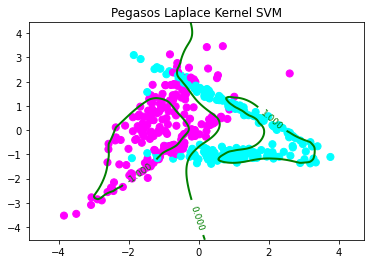

```python
run_kernel_pegasos('2', epochs=2000, gamma=0.5)
```

```
0.3875
```

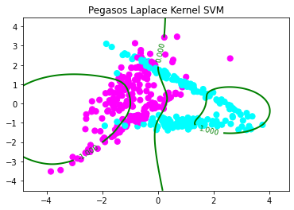

```python
run_kernel_pegasos('2', epochs=2000, gamma=0.1)
```

$\gamma$ controls the bias-complexity trade-off. Small $\gamma$ leads to high bias and low variance (underfitting) and large $\gamma$ leads to low bias and high variance (overfitting), because larger $\gamma$ forces the boundary to consider fewer nearby points. The Laplace kernel can make boundaries that fit the data better, but is prone to overfitting.